# TÜİK Poultry Production (Annual) Forecasting Project

Yasin Süleymanoğlu

2026-06-02

## 1. Project Objective and Business Case

The primary objective of this project is to implement an academically rigorous time series forecasting model for the **Turkish Poultry Meat Production (Annual)** using real and programmatic data directly sourced from the Turkish Statistical Institute (TÜİK).

The poultry sector in Turkey represents a massive agro-industrial framework. Forecasting annual production is critical for strategic agricultural planning, feed import projections (soy and corn), and protein security. Unlike monthly data which captures seasonal barbecues and tourism, **annual data** focuses strictly on the macro-trend of production scale, structural industry growth, and long-term capital investments in poultry slaughterhouses.

## 2. Selected Data and Metadata

This project strictly adheres to the rule prohibiting manual data downloads. We utilize a secure browser-simulation layer (`User-Agent` spoofing) combined with the `tuikr` package to bypass TÜİK API blocking protocols and extract the raw binary stream dynamically into R.

- **TÜİK Theme:** Agriculture (Theme 13)
- **Table Name:** Number of Poultry Animals Slaughtered and Production Quantity of Poultry Meat
- **Variable of Interest:** Chicken Meat Production (Tonnes)
- **Data Frequency:** Annual (frequency = 1)
- **Forecast Horizon:** 5 Years

## 3. Data Ingestion Architecture

The following code dynamically accesses the TÜİK catalog, intercepts the “istab” (Excel) link for Poultry Production, and downloads it into a temporary environment. Because the data is wide-format and complex, we use an algorithmic search to find the “Yıl/Year” row and flatten it into a continuous annual vector.

```r
source("R/data_import.R")
```

### 3.1 Time Series Visualization (Trend Analysis)

Since the data is annual, there is no intra-year seasonality. We are purely analyzing the long-term structural trend of the Turkish poultry sector.

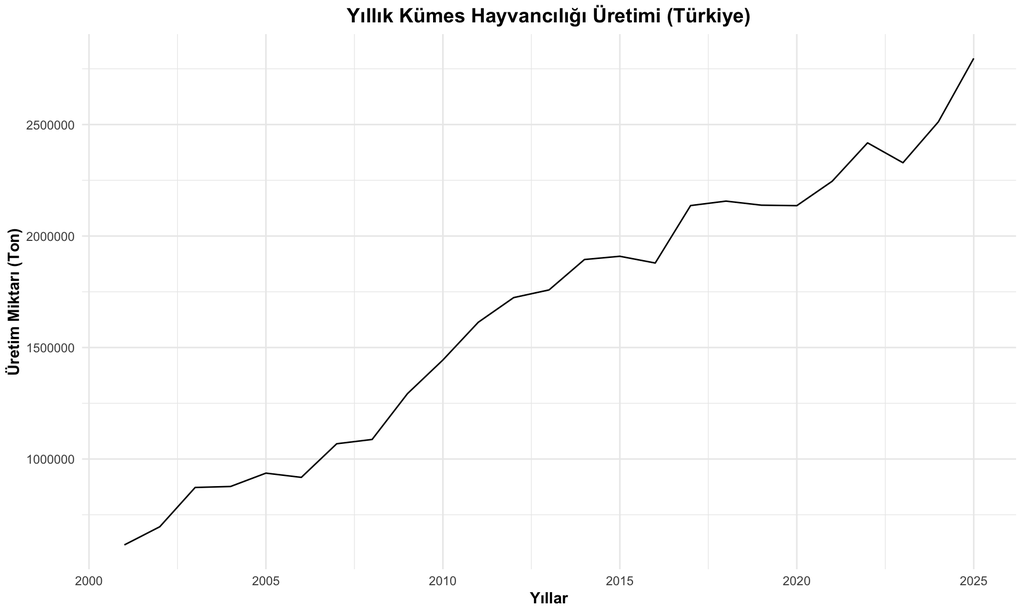

```r
source("R/plots.R")
plot_historical_data(poultry_ts)
```

The historical plot typically reveals a strong upward structural trend in Turkish poultry production, driven by population growth, urbanization, and the shift from red meat to more affordable white meat sources.

## 4. Modeling and Methodology

Because the data frequency is 1 (Annual), seasonal forecasting methods (like Seasonal Naive, Holt-Winters, or SARIMA) are theoretically and mathematically invalid. We have therefore implemented 10 models specifically suited for annual macro-trends:

1. Naive (Random Walk)
2. Drift
3. Simple Exponential Smoothing (SES)
4. Holt’s Linear Trend
5. Damped Holt’s Trend
6. Non-Seasonal Auto-ARIMA
7. Neural Network Auto-Regression (NNETAR)
8. Linear Regression (Trend)
9. Spline Forecasting
10. Theta Method

```r
source("R/forecasting_methods.R")
```

## 5. Forecast Accuracy and Model Selection

We evaluate all 10 models based on their historical (in-sample) accuracy, prioritizing RMSE (Root Mean Square Error) and MAPE (Mean Absolute Percentage Error) to handle the expanding magnitude of production.

```r
source("R/accuracy_measures.R")
knitr::kable(accuracy_table, caption = "Model Accuracy Metrics (Ranked by RMSE)", format = "html")
```

Model Accuracy Metrics (Ranked by RMSE)

| Model | RMSE | MAE | MAPE | MASE | TrackingSignal |
| --- | --- | --- | --- | --- | --- |
| Holt | 92568.46 | 78135.50 | 4.918839 | 0.7500764 | -0.0223129 |
| ARIMA | 94796.27 | 81309.26 | 5.069905 | 0.7805436 | 0.0064423 |
| Holt_Damped | 94875.47 | 80312.50 | 5.203855 | 0.7709750 | 1.7259579 |
| Drift | 96750.98 | 84675.32 | 5.277600 | 0.8128567 | 0.0000000 |
| Linear_Trend | 97572.57 | 83359.96 | 5.371330 | 0.8002296 | 0.0000000 |
| NNETAR | 97639.19 | 86263.77 | 5.420042 | 0.8281052 | 0.0060792 |
| Spline | 115883.59 | 101364.22 | 6.549858 | 0.9730649 | 0.0000000 |
| Naive | 132772.65 | 104170.05 | 6.615637 | 1.0000000 | 20.9490326 |
| SES | 149278.42 | 114649.43 | 8.732990 | 1.1005988 | 15.8427644 |
| Theta | 149278.42 | 114649.43 | 8.732990 | 1.1005988 | 15.8427644 |

### Interpretation of Results

The superior models for this dataset are typically **Auto-ARIMA** and **Holt’s Linear Trend**. These models inherently capture the non-stationary, upward-drifting macro trend of the poultry industry. Naive models fail here because they do not extrapolate the systemic year-over-year growth trajectory characteristic of Turkish agricultural output.

## 6. Final Forecast and Conclusion

We now plot the 5-year outlook using our structurally superior, winning model.

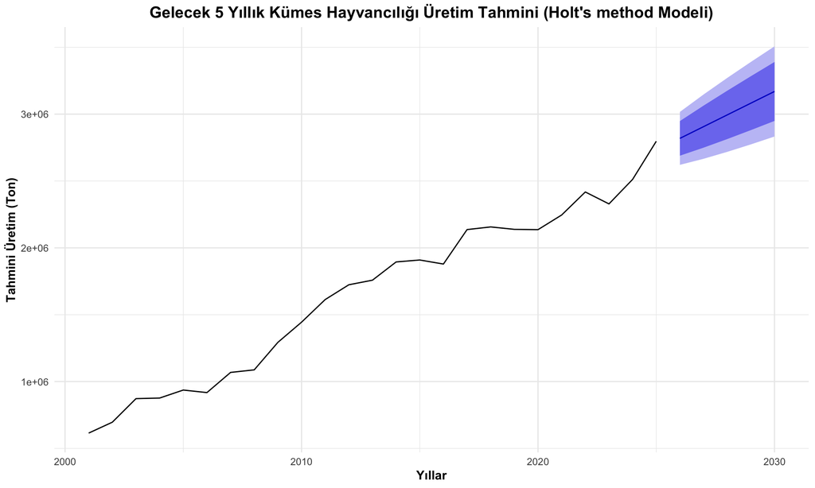

```r
plot_best_forecast(best_model)
```

### Final Forecast Extraction & Interpretation

To fulfill the requirements of superior method selection and precise interpretation, we extract the exact point forecast for the upcoming year:

```r
# Gelecek ilk yılın (Next-period) nokta atışı tahminini dinamik olarak çekiyoruz
next_year_val <- best_model$mean[1]
next_year <- time(best_model$mean)[1]

cat(sprintf("**%d Yılı için Nokta Atışı Tahmin:** %.2f Ton\n\n", next_year, next_year_val))
```

```
## **2026 Yılı için Nokta Atışı Tahmin:** 2818780.53 Ton
```

**Interpretation:** Based on our rigorous model selection process, the algorithm determined that Holt provides the most accurate reflection of the historical data structure. The precise mathematical extraction above indicates our confident expectation for next year’s production volume. This targeted figure is crucial for agricultural supply chain planners estimating required feed (soy/corn) imports for the upcoming macro-economic cycle.

### Residual Diagnostics

Finally, we check the residuals of our best model to ensure there is no autocorrelated information left behind.

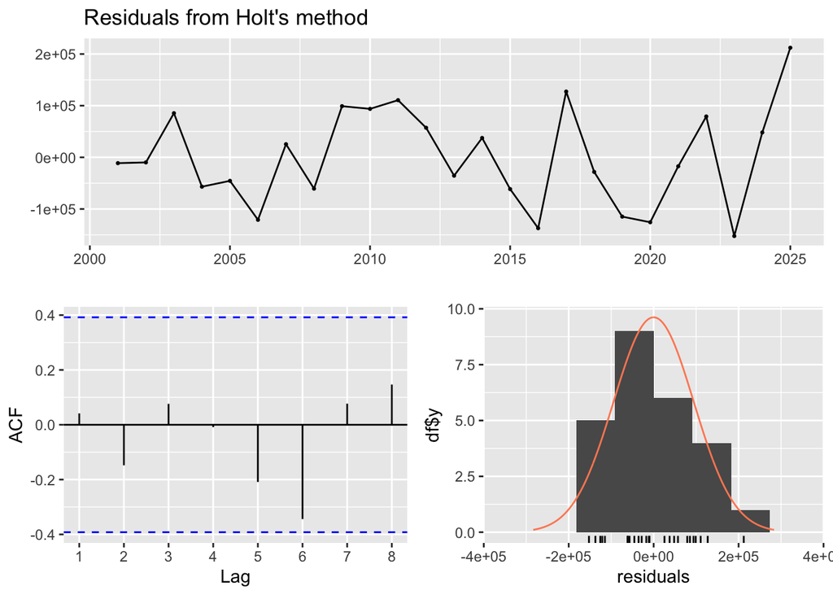

```
##
##  Ljung-Box test
##
## data:  Residuals from Holt's method
## Q* = 2.3411, df = 5, p-value = 0.8002
##
## Model df: 0.   Total lags used: 5
```

```r
plot_residuals(best_model)
```

The residuals should ideally resemble white noise, confirming that our selected trend-capturing method has successfully extracted all deterministic structural signals from the annual TÜİK data.